# Project Proposal

### 1) Name

Emerald Ouyang

### 2) Project Topic/Title

Comparative Analysis of Red and White Wine Quality Prediction Models

### 3) Inspiration

Explain the reason for your choice of data. Why is it interesting to you? Why do you think it is worth exploring for this project? Include any motivations or background that you believe is relevant. **(0.5 points)**

This dataset is ideal for exploring wine quality prediction due to its real-world relevance in the wine industry and rich feature set. By comparing red and white wines, we can identify key factors influencing quality and determine whether a single or separate models perform better for each type. The project provides valuable insights for winemakers, enhances machine learning skills, and offers a practical application of predictive analytics in food science.

### 4) Data

- Identify and describe your data source(s). Share any related links and/or citations.
- **Using some code**, demonstrate that you have been able to read the data and (**using some code again**) give a brief overview of the data:
  - How many observations?
  - How many variables? How many of them are continuous and how many of them are categorical?
  - Are there any missing values? Will cleaning/imputing be necessary?
  - Is there any substantial correlation between the variables? This can be all variables in the data or only your variables of interest.

**(2 points)**

- Link: https://archive.ics.uci.edu/dataset/186/wine+quality
- This data source named “Wine Quality” posted on UCI machine learning repository includes 2 datasets both containing the physiochemical factor that affect the quality of wine.
- there are 1599 observation for the redwine dataset, and 4898 observation for the whitewine dataset.
- there are 12 variables for both dataset and all 12 are continuous variable
- there are no missing values, no cleaning/imputiong necessary
- there are some substantial correlation between density and alcohol, ph and fixed acidity, density and fixed acidity.

```python
import pandas as pd
import numpy as np

red = pd.read_csv('winequality-red.csv', sep=';')
white = pd.read_csv('winequality-white.csv', sep=';')
print(red.head())
print(white.head())
```

```
   fixed acidity  volatile acidity  citric acid  residual sugar  chlorides  \
0            7.4              0.70         0.00             1.9      0.076
1            7.8              0.88         0.00             2.6      0.098
2            7.8              0.76         0.04             2.3      0.092
3           11.2              0.28         0.56             1.9      0.075
4            7.4              0.70         0.00             1.9      0.076

   free sulfur dioxide  total sulfur dioxide  density    pH  sulphates  \
0                 11.0                  34.0   0.9978  3.51       0.56
1                 25.0                  67.0   0.9968  3.20       0.68
2                 15.0                  54.0   0.9970  3.26       0.65
3                 17.0                  60.0   0.9980  3.16       0.58
4                 11.0                  34.0   0.9978  3.51       0.56

   alcohol  quality
```

[output cut: 25 more lines]

```python
print(red.shape)
print(white.shape)
print(red.columns)
```

```
(1599, 12)
(4898, 12)
Index(['fixed acidity', 'volatile acidity', 'citric acid', 'residual sugar',
       'chlorides', 'free sulfur dioxide', 'total sulfur dioxide', 'density',
       'pH', 'sulphates', 'alcohol', 'quality'],
      dtype='object')
```

```python
red.dtypes
```

```
fixed acidity           float64
volatile acidity        float64
citric acid             float64
residual sugar          float64
chlorides               float64
free sulfur dioxide     float64
total sulfur dioxide    float64
density                 float64
pH                      float64
sulphates               float64
alcohol                 float64
quality                   int64
dtype: object
```

```python
print(red.isnull().sum())
print(white.isnull().sum())
```

```
fixed acidity           0
volatile acidity        0
citric acid             0
residual sugar          0
chlorides               0
free sulfur dioxide     0
total sulfur dioxide    0
density                 0
pH                      0
sulphates               0
alcohol                 0
quality                 0
dtype: int64
fixed acidity           0
volatile acidity        0
citric acid             0
residual sugar          0
chlorides               0
free sulfur dioxide     0
total sulfur dioxide    0
density                 0
pH                      0
sulphates               0
alcohol                 0
quality                 0
dtype: int64
```

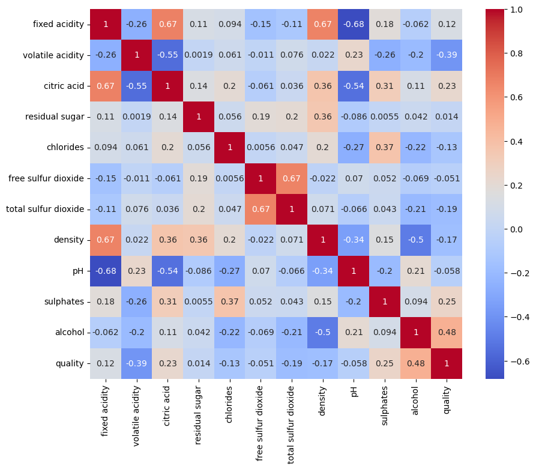

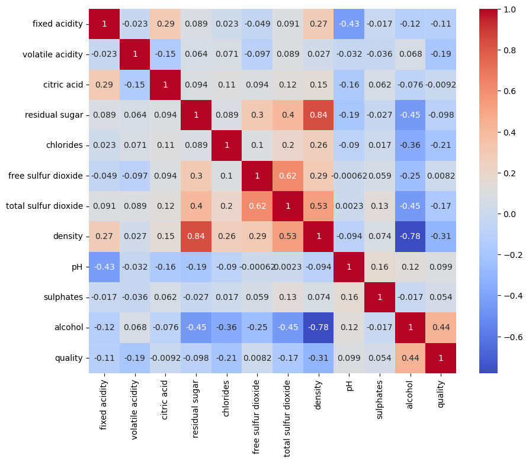

```python
import matplotlib.pyplot as plt
import seaborn as sns

plt.figure(figsize=(10,8))
sns.heatmap(red.corr(), annot=True, cmap='coolwarm')
plt.show()

plt.figure(figsize=(10,8))
sns.heatmap(white.corr(), annot=True, cmap='coolwarm')
plt.show()
```

### 5) Questions

Answer the following questions to describe your plan for the project content.

- Is this a regression or a classification problem?
- Which variable will be the response and which variables will be your predictors?
- What is your plan to develop a model? How many models are you planning to train? **Note that using a single model with all predictors at once is not acceptable. You need to start with a simple model. Keep adding predictors and observe the changes.**
- How will you explore the non-linearities in the data?
- Are there any variables that you are planning to exclude from your models? If yes, explain why.
- How will you evaluate the prediction performance of your models? Justify your choice.
- How will you perform inference on your models?

**(2 points)**

- this is a regression problem, the goal is to predic the exact wine quality score.
- response var: quality(from 0-10)
- predictor vars: ‘fixed acidity’, ‘volatile acidity’, ‘citric acid’, ‘residual sugar’, ‘chlorides’, ‘free sulfur dioxide’, ‘total sulfur dioxide’, ‘density’, ‘pH’, ‘sulphates’, ‘alcohol’
- start with a simple linear regression model using one predictor, then multiple regression model which incrementally add more predictors to observe improvements in model performance. I plan to train separate models for red and white wines to compare their predictive accuracy, then develop a combined model includes color as a predictor to assess and compare with the previous models.
- use scatterplots and polynomial regression, fit interaction terms to capture feature dependencies
- no variables to be excluded as all are important factors to access the quality of wine
- use MSE, RMSE and MAE to evaluate the performance of my models, also compare r-squared to assess the variance of different models.
- conduct t-test, hypothesis testing, and coefficient analysis which is to use L1 regularization to reduce multicollinearity and identify which factors most strongly influence wine quality.

### 6) Stakeholders

Who would be the stakeholders of this project, i.e. who would be interested in hearing your results and how would those results benefit them? **(0.5 points)**

Winemakers, vineyards, customers, food scientists, retailers, restaruants.